# Population Aging in the Netherlands vs Population Density

BoatGoBinter

2025-11-29

# Introduction

Population aging has become one of the most significant demographic shifts of the 21st century. Many in Europe, including the Netherlands, are experiencing rising proportions of elderly due to declining birth rates and the increasing life expectancy. As someone who has studied and lived in Korea, a country that has the worst aging crisis in the world, this topic holds personal relevance and importance. Understanding how aging varies across regions can help us identify where we need to pay close attention to issues that are creating from an aging population, like social, economic, and healthcare challenges.

In this study, I compare Dutch provinces to analyze which regions are aging the most and, in particular, test whether provinces with higher population density tend to have younger or older populations. Density may be an important factor because urban areas have a reputation for younger, student-filled population while rural areas have been known to have aging population with a shrinking labor force. Thus, my research question is: How is population density related to the share of elderly residents (65+) across Dutch provinces?

# Background

The theory behind population aging is when the amount of elderly increases compared to younger populations. This is phenomenon is occurring globally, specifically in Western European and East Asian countries, and it will continue to increase in the future decades (UN DESA, 2022). South Korea is a country that is at the forefront of this problem and it is illustrating the problems that can arise from it like social and economic pressures (OECD 2023). The Netherlands is also encountering a rise in an aging population (see **graphing**), and it plays an important role in demographic structure. Urban regions with a high density can attract younger populations. So, rural regions may lost their younger populations for these reasons. For this reason, testing the relationship between population density and aging can reveal whether an urban-rural divide can explain possible aging patterns in the Netherlands.

United Nations Department of Economic and Social Affairs (UN DESA). *World Population Prospects 2022*. https://population.un.org/wpp/

OECD (2023). *Aging and Demographic Change in Korea*. https://www.oecd.org/korea/

# Data and Methods

### Load Libraries:

```r
library(tidyverse)
library(sf)
library(tmap)
library(readr)
```

### Importing the Data

For this project, my response variable is the percentage of residents aged 65 and over in each province (pct_65_plus), and my main predictor variable is population density per square kilometer (population_density_per_sqr_kilometer). Both are joined to the same provincial geometry so they can be analyzed and mapped together.

```r
pop_csv <- "https://drive.google.com/uc?export=download&id=18K6cuNFoosLUOn5nVbWw-ubpXZRxtlCJ"
prov_geojson <- "https://drive.google.com/uc?export=download&id=1UMOJRm82Y8Xrbc1BQsHoxCNVpbx9Xe1Q"

p_pop <- read_csv(pop_csv)
p_map <- st_read(prov_geojson)
```

#### This data comes from two different sources. The CSV with the population data comes from https://allecijfers.nl. AlleCijfers pulls from a variety of official open-data sources. This data is from the CBS – Centraal Bureau voor de Statistiek. The GeoJson comes from Basisregistratie Kadaster (Kadaster.nl). Kadaster is the official Dutch authority responsible for: national cadastral records property boundaries administrative geography official provincial and municipal boundaries.

Here is what the variables from both datasets represent:

Dutch Provincial Age Population Demographics.csv variables:

Provincienaam – The name of the Dutch province.  
% 0 tot 15 jaar – Percentage of the population aged 0–15.  
% 15 tot 25 jaar – Percentage of the population aged 15–25.  
% 25 tot 45 jaar – Percentage of the population aged 25–45.  
% 45 tot 65 jaar – Percentage of the population aged 45–65.  
% 65 jaar of ouder – Percentage of the population aged 65 and older.

Netherlands Provincial Maps.geojson variables:

geo_point_2d – A latitude–longitude point for the centroid of the province.  
year – The reference year of the geographic dataset.  
prov_code – The internal province identifier used by Opendatasoft.  
prov_name – The official name of the province.  
prov_area_code – The administrative area code assigned to the province.  
prov_type – The administrative unit type (province).  
prov_cbs_code – The CBS (Statistics Netherlands) official province code.

```r
density_df <- tribble(
  ~provincienaam,      ~population_density_per_sqr_kilometer,
  "Drenthe",            191,
  "Friesland",          197,
  "Zeeland",            220,
  "Groningen",          257,
  "Flevoland",          315,
  "Overijssel",         357,
  "Gelderland",         430,
  "Limburg",            526,
  "Noord-Brabant",      536,
  "Utrecht",            935,
  "Noord-Holland",      1109,
  "Zuid-Holland",       1410
)
```

**This data is from Statista and I manually added here. Population density in the Netherlands 2023, by province Published by S. Galan, Nov 28, 2025**

```r
popovertime <- tribble(
  ~year, ~pct_65_plus,
  2013, 17.4,
  2014, 17.8,
  2015, 18.2,
  2016, 18.7,
  2017, 19.1,
  2018, 19.5,
  2019, 19.9,
  2020, 20.2,
  2021, 20.4,
  2022, 20.9,
  2023, 21.2,
  2024, 21.4
)
```

### Cleaning and merging the data

This just cleans and standardizes the population dataset by renaming the columns and converting all percentage values into numeric format so they can be analyzed and mapped correctly.

Here we need to fix the provincial name variables and join

```r
p_pop_clean <- p_pop |>
  rename(
    provincienaam = Provincienaam,
    pct_0_15 = `% 0 tot 15 jaar`,
    pct_15_25 = `% 15 tot 25 jaar`,
    pct_25_45 = `% 25 tot 45 jaar`,
    pct_45_65 = `% 45 tot 65 jaar`,
    pct_65_plus = `% 65 jaar of ouder`
  ) |>
  mutate(
    across(
      c(pct_0_15, pct_15_25, pct_25_45, pct_45_65, pct_65_plus),
      ~ readr::parse_number(.x)
    ),
    provincienaam = if_else(
      provincienaam == "Fryslân (Friesland)",
      "Friesland",
      provincienaam
    )
  ) |>
  # add density
  left_join(density_df, by = "provincienaam") |>
  # this will be our join key
  mutate(prov_join = provincienaam)

p_map_clean <- p_map |>
  mutate(
    prov_join = case_when(
      prov_name %in% c("Fryslân", "Fryslan") ~ "Friesland",
      TRUE ~ as.character(prov_name)
    )
  )

# join and reproject
nl_map <- p_map_clean |>
  left_join(p_pop_clean, by = "prov_join") |>
  st_transform(28992)
```

st_transform(28992) converts the map’s coordinates into the Dutch national projection

```r
p_pop_clean |> select(provincienaam, pct_65_plus, population_density_per_sqr_kilometer)
```

```
## # A tibble: 12 × 3
##    provincienaam pct_65_plus population_density_per_sqr_kilometer
##    <chr>               <dbl>                                <dbl>
##  1 Groningen              21                                  257
##  2 Friesland              23                                  197
##  3 Drenthe                25                                  191
##  4 Overijssel             21                                  357
##  5 Flevoland              16                                  315
##  6 Gelderland             22                                  430
##  7 Utrecht                18                                  935
##  8 Noord-Holland          19                                 1109
##  9 Zuid-Holland           19                                 1410
## 10 Zeeland                25                                  220
## 11 Noord-Brabant          22                                  536
## 12 Limburg                26                                  526
```

#### Descriptive Statistics:

```r
#vector creation
age_vars <- c("pct_65_plus", "population_density_per_sqr_kilometer")

summary(p_pop_clean[age_vars])
```

```
##   pct_65_plus    population_density_per_sqr_kilometer
##  Min.   :16.00   Min.   : 191.0
##  1st Qu.:19.00   1st Qu.: 247.8
##  Median :21.50   Median : 393.5
##  Mean   :21.42   Mean   : 540.2
##  3rd Qu.:23.50   3rd Qu.: 635.8
##  Max.   :26.00   Max.   :1410.0
```

```r
p_pop_clean |>
summarise(
mean_65plus = mean(pct_65_plus),
sd_65plus = sd(pct_65_plus),
mean_density = mean(population_density_per_sqr_kilometer),
sd_density = sd(population_density_per_sqr_kilometer)
)
```

```
## # A tibble: 1 × 4
##   mean_65plus sd_65plus mean_density sd_density
##         <dbl>     <dbl>        <dbl>      <dbl>
## 1        21.4      3.06         540.       399.
```

The summary statistics show substantial variation in both aging and population density across Dutch provinces. The average share of elderly residents is 21.4%, but this ranges from 16% in the youngest provinces to 26% in the oldest, indicating strong regional demographic differences. Population density varies even more dramatically from 191 to 1,410 people per km² with a very large standard deviation, showing that the Netherlands contains both extremely urbanized and highly rural provinces, which helps explain some of the observed differences in aging patterns.

#### Graphing

```r
#long format
p_long <- p_pop_clean |>
  pivot_longer(
    cols = all_of(age_vars),
    names_to = "variable",
    values_to = "percent"
  )
```

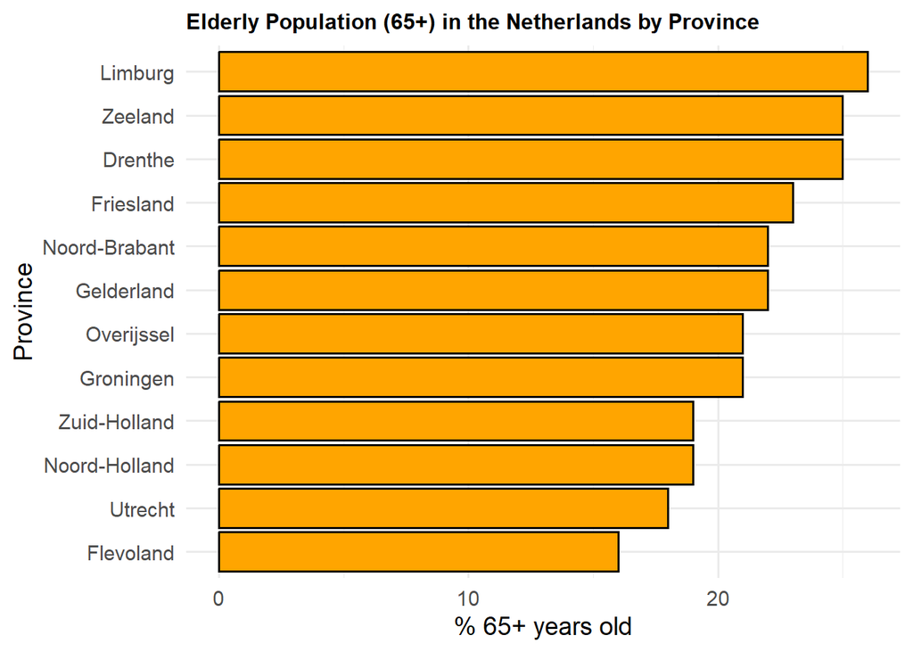

```r
pdist_barplot <-
  ggplot(p_pop_clean, aes(x = reorder(provincienaam, pct_65_plus),
                      y = pct_65_plus)) +
  geom_col(fill = "orange", color = "black") +
  coord_flip() +
  labs(
    title = "Elderly Population (65+) in the Netherlands by Province",
    x = "Province",
    y = "% 65+ years old",
    #caption = "Credit: BoatGoBinter" - my GitHub Account
  ) +
  theme_minimal(base_size = 14) +
  theme(
    plot.title = element_text(size = 12, face = "bold"),
    plot.caption = element_text(hjust = 1, size = 10, face = "italic")
    )
pdist_barplot
```

Exploring data a little more

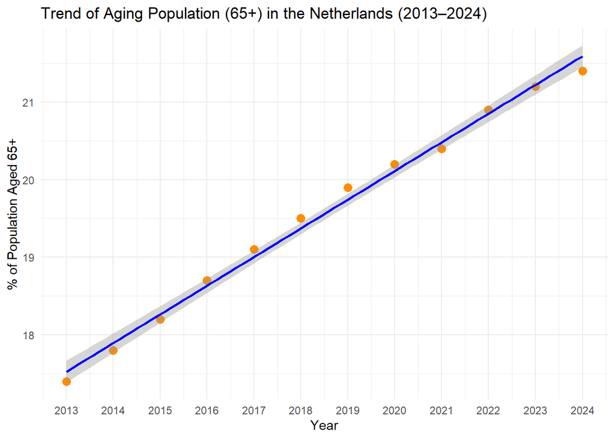

```r
aging_pop_trend <-
ggplot(popovertime, aes(x = year, y = pct_65_plus)) +
  geom_point(size = 3, color = "darkorange") +
  geom_smooth(method = "lm", se = TRUE, color = "blue") +
   scale_x_continuous(breaks = unique(popovertime$year))+
  labs(
    title = "Trend of Aging Population (65+) in the Netherlands (2013–2024)",
    x = "Year",
    y = "% of Population Aged 65+"
  ) +
  theme_minimal()
aging_pop_trend
```

I put the above graph as a source for the evidence that the Netherlands is aging. Source:(https://tradingeconomics.com/netherlands/proportion-of-population-aged-65-over-eurostat-data.html)

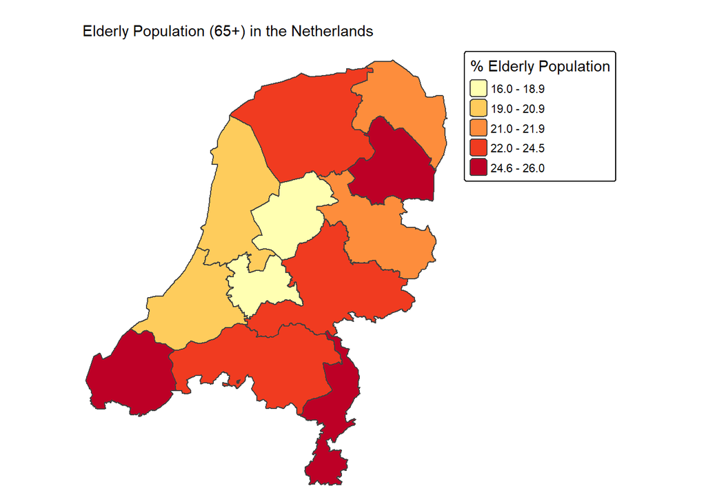

```r
tmap_options(component.autoscale = FALSE)
eldpop_map <-
  tm_shape(nl_map) +
    tm_polygons(
      fill = "pct_65_plus",
      fill.scale = tm_scale_intervals(
        style = "quantile",
        n = 5,
        values = "brewer.yl_or_rd"   # YlOrRd
      ),
      fill.legend = tm_legend(title = "% Elderly Population")
    ) +
    tm_title(
      "Elderly Population (65+) in the Netherlands",
      size = 0.9,
    ) +
    tm_layout(
      legend.outside = TRUE,
      frame = FALSE
    )
eldpop_map
```

```r
nl_map <- p_map_clean |>
  left_join(p_pop_clean, by = "prov_join") |>
  st_transform(28992)
```

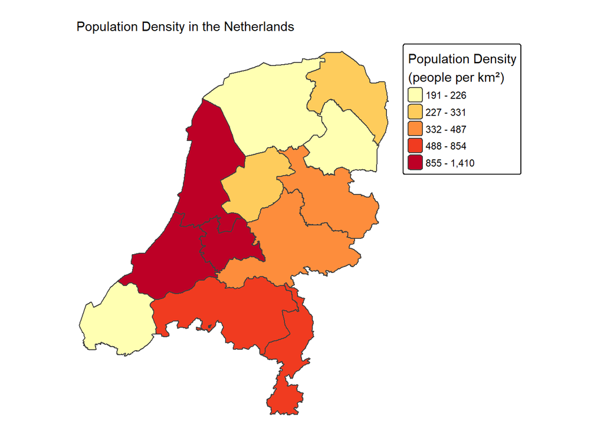

```r
tmap_options(component.autoscale = FALSE)

popdens_map <-
  tm_shape(nl_map) +
  tm_polygons(
    fill = "population_density_per_sqr_kilometer",
    fill.scale = tm_scale_intervals(
      style = "quantile",
      n = 5,
       values = "brewer.yl_or_rd"
    ),
    fill.legend = tm_legend(title = "Population Density\n(people per km²)")
  ) +
  tm_title(
    "Population Density in the Netherlands",
    size = 0.9
  ) +
  tm_layout(
    legend.outside = TRUE,
    frame = FALSE
  )

popdens_map
```

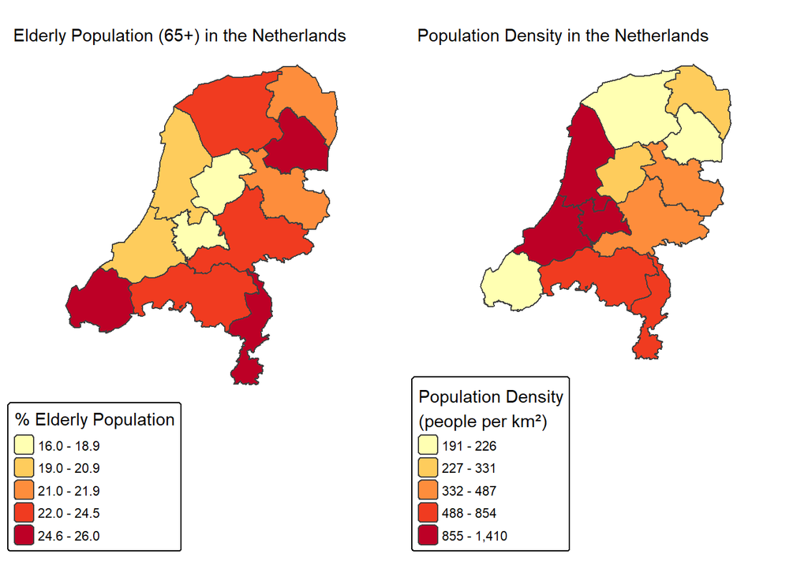

```r
comparison_map <- tmap_arrange(
  eldpop_map,
  popdens_map,
  ncol = 2
)
comparison_map
```

### Histogram that shows % Elderly across the Dutch Provinces

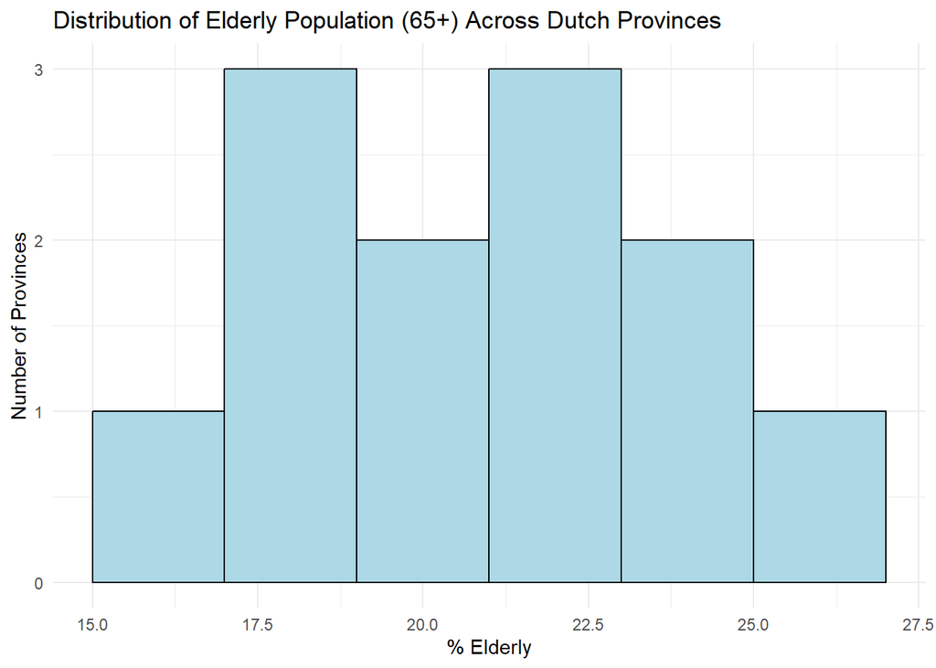

```r
hist <- ggplot(p_pop_clean, aes(x = pct_65_plus)) +
  geom_histogram(binwidth = 2, fill = "lightblue", color = "black") +
  labs(
    title = "Distribution of Elderly Population (65+) Across Dutch Provinces",
    x = "% Elderly",
    y = "Number of Provinces"
  ) +
  theme_minimal()

hist
```

## Linear Regression

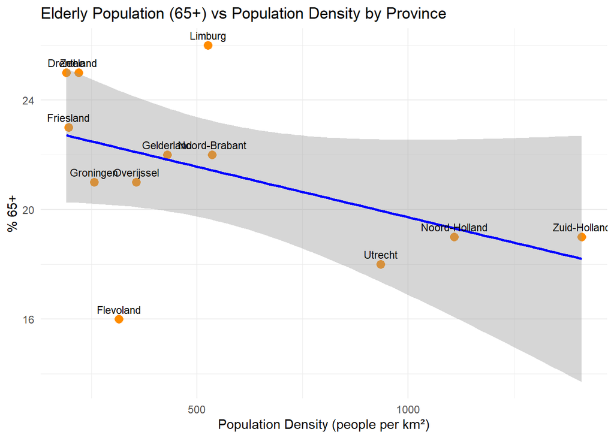

```r
ggplot(p_pop_clean,
       aes(x = population_density_per_sqr_kilometer,
           y = pct_65_plus,
           label = provincienaam)) +
  geom_point(color = "darkorange", size = 3) +
  geom_smooth(method = "lm", se = TRUE, color = "blue") +
  geom_text(vjust = -0.7, size = 3) +
  labs(
    title = "Elderly Population (65+) vs Population Density by Province",
    x = "Population Density (people per km²)",
    y = "% 65+"
  ) +
  theme_minimal()
```

## **Flevoland is a new province. It was mostly seabed until the 1950s and only became a province in 1986. So, I would consider this an outlier that should not be considered.**

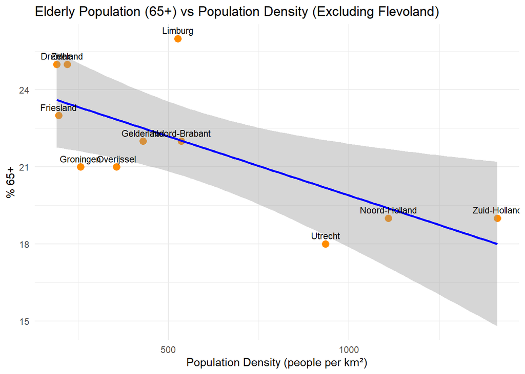

```r
lin_reg_no_flevo <- ggplot(
  p_pop_clean |> filter(provincienaam != "Flevoland"),
  aes(
    x = population_density_per_sqr_kilometer,
    y = pct_65_plus,
    label = provincienaam
  )
) +
  geom_point(color = "darkorange", size = 3) +
  geom_smooth(method = "lm", se = TRUE, color = "blue") +
  geom_text(vjust = -0.7, size = 3) +
  labs(
    title = "Elderly Population (65+) vs Population Density (Excluding Flevoland)",
    x = "Population Density (people per km²)",
    y = "% 65+"
  ) +
  theme_minimal()
lin_reg_no_flevo
```

```r
model_no_flev <- lm(
  pct_65_plus ~ population_density_per_sqr_kilometer,
  data = p_pop_clean |> filter(provincienaam != "Flevoland")
)

summary(model_no_flev)
```

```
##
## Call:
## lm(formula = pct_65_plus ~ population_density_per_sqr_kilometer,
##     data = filter(p_pop_clean, provincienaam != "Flevoland"))
##
## Residuals:
##     Min      1Q  Median      3Q     Max
## -2.3058 -1.2138 -0.3878  1.1935  3.9312
##
## Coefficients:
##                                       Estimate Std. Error t value Pr(>|t|)
## (Intercept)                          24.487662   1.035297  23.653 2.06e-09 ***
## population_density_per_sqr_kilometer -0.004599   0.001512  -3.042    0.014 *
## ---
## Signif. codes:  0 '***' 0.001 '**' 0.01 '*' 0.05 '.' 0.1 ' ' 1
##
## Residual standard error: 1.971 on 9 degrees of freedom
## Multiple R-squared:  0.5069, Adjusted R-squared:  0.4521
## F-statistic: 9.252 on 1 and 9 DF,  p-value: 0.01398
```

Relationship becomes significant (p = 0.014) R^2 doubles from 0.23 -> 0.51 Slope becomes more negative (–0.0046) Interpretation: Higher-density provinces have younger populations; Flevoland was potentially masking this trend.

## Spatial ANOVA Model

```r
p_pop_clean <- p_pop_clean |>
  mutate(
    density_group = ntile(population_density_per_sqr_kilometer, 3),
    density_group = case_when(
      density_group == 1 ~ "Low Density",
      density_group == 2 ~ "Medium Density",
      density_group == 3 ~ "High Density"
    )
  )
```

```r
anova_density_all <- aov(pct_65_plus ~ density_group, data = p_pop_clean)
summary(anova_density_all)
```

```
##               Df Sum Sq Mean Sq F value Pr(>F)
## density_group  2  32.17  16.083   2.046  0.185
## Residuals      9  70.75   7.861
```

```r
model_lm_all <- lm(
  pct_65_plus ~ population_density_per_sqr_kilometer,
  data = p_pop_clean
)
```

```r
p_pop_no_flev <- p_pop_clean |>
  dplyr::filter(provincienaam != "Flevoland")
model_lm_no_flev <- lm(
  pct_65_plus ~ population_density_per_sqr_kilometer,
  data = p_pop_no_flev
)
```

```r
summary(model_lm_all)
```

```
##
## Call:
## lm(formula = pct_65_plus ~ population_density_per_sqr_kilometer,
##     data = p_pop_clean)
##
## Residuals:
##     Min      1Q  Median      3Q     Max
## -6.2490 -1.1862  0.2454  1.1711  4.5307
##
## Coefficients:
##                                       Estimate Std. Error t value Pr(>|t|)
## (Intercept)                          23.412995   1.403901  16.677 1.26e-08 ***
## population_density_per_sqr_kilometer -0.003695   0.002121  -1.742    0.112
## ---
## Signif. codes:  0 '***' 0.001 '**' 0.01 '*' 0.05 '.' 0.1 ' ' 1
##
## Residual standard error: 2.81 on 10 degrees of freedom
## Multiple R-squared:  0.2329, Adjusted R-squared:  0.1561
## F-statistic: 3.035 on 1 and 10 DF,  p-value: 0.1121
```

```r
summary(model_lm_no_flev)
```

```
##
## Call:
## lm(formula = pct_65_plus ~ population_density_per_sqr_kilometer,
##     data = p_pop_no_flev)
##
## Residuals:
##     Min      1Q  Median      3Q     Max
## -2.3058 -1.2138 -0.3878  1.1935  3.9312
##
## Coefficients:
##                                       Estimate Std. Error t value Pr(>|t|)
## (Intercept)                          24.487662   1.035297  23.653 2.06e-09 ***
## population_density_per_sqr_kilometer -0.004599   0.001512  -3.042    0.014 *
## ---
## Signif. codes:  0 '***' 0.001 '**' 0.01 '*' 0.05 '.' 0.1 ' ' 1
##
## Residual standard error: 1.971 on 9 degrees of freedom
## Multiple R-squared:  0.5069, Adjusted R-squared:  0.4521
## F-statistic: 9.252 on 1 and 9 DF,  p-value: 0.01398
```

### Analysis:

From this model we can see that the percentage of elderly residents in the Netherlands is systematically related to how densely populated a province is. The regression without Flevoland shows a clear negative slope: as population density increases, the share of residents aged 65+ tends to decrease, and this relationship is statistically significant (p ≈ 0.014). This suggests that more rural, less dense provinces carry a heavier aging burden, while the denser areas are relatively younger on average.

# Conclusions

## What might you do differently next time?

Next time, I would try to include additional spatial factors that might explain aging, such as migration patterns, housing characteristics, or access to services, rather than just density alone.